# Take a `moderndive` into introductory linear regression with R

Albert Y. Kim, Chester Ismay, and Max Kuhn

2026-08-04

# Summary

We present the [`moderndive`](https://moderndive.github.io/moderndive/) R package of datasets and functions for [tidyverse](https://tidyverse.org/)-friendly introductory linear regression (Wickham, Averick, et al. 2019). These tools leverage the well-developed `tidyverse` and `broom` packages to facilitate 1) working with regression tables that include confidence intervals, 2) accessing regression outputs on an observation level (e.g. fitted/predicted values and residuals), 3) inspecting scalar summaries of regression fit (e.g. $R^2$, $R^2_{adj}$, and mean squared error), and 4) visualizing parallel slopes regression models using `ggplot2`-like syntax (Wickham, Chang, et al. 2019; Robinson and Hayes 2019). This R package is designed to supplement the book “Statistical Inference via Data Science: A ModernDive into R and the Tidyverse” (Ismay and Kim 2019). Note that the book is also available online at https://moderndive.com and is referred to as “ModernDive” for short.

# Statement of Need

Linear regression has long been a staple of introductory statistics courses. While the curricula of introductory statistics courses has much evolved of late, the overall importance of regression remains the same (American Statistical Association Undergraduate Guidelines Workgroup 2016). Furthermore, while the use of the R statistical programming language for statistical analysis is not new, recent developments such as the `tidyverse` suite of packages have made statistical computation with R accessible to a broader audience (Wickham, Averick, et al. 2019). We go one step further by leveraging the `tidyverse` and the `broom` packages to make linear regression accessible to students taking an introductory statistics course (Robinson and Hayes 2019). Such students are likely to be new to statistical computation with R; we designed `moderndive` with these students in mind.

# Introduction

Let’s load all the R packages we are going to need.

```r
library(moderndive)
library(ggplot2)
library(dplyr)
library(knitr)
library(broom)
```

Let’s consider data gathered from end of semester student evaluations for a sample of 463 courses taught by 94 professors from the University of Texas at Austin (Diez et al. 2015). This data is included in the `evals` data frame from the `moderndive` package.

In the following table, we present a subset of 9 of the 14 variables included for a random sample of 5 courses[^1]:

1. `ID` uniquely identifies the course whereas `prof_ID` identifies the professor who taught this course. This distinction is important since many professors taught more than one course.
2. `score` is the outcome variable of interest: average professor evaluation score out of 5 as given by the students in this course.
3. The remaining variables are demographic variables describing that course’s instructor, including `bty_avg` (average “beauty” score) for that professor as given by a panel of 6 students.[^2]

| ID | prof_ID | score | age | bty_avg | gender | ethnicity | language | rank |
| --- | --- | --- | --- | --- | --- | --- | --- | --- |
| 129 | 23 | 3.7 | 62 | 3.000 | male | not minority | english | tenured |
| 109 | 19 | 4.7 | 46 | 4.333 | female | not minority | english | tenured |
| 28 | 6 | 4.8 | 62 | 5.500 | male | not minority | english | tenured |
| 434 | 88 | 2.8 | 62 | 2.000 | male | not minority | english | tenured |
| 330 | 66 | 4.0 | 64 | 2.333 | male | not minority | english | tenured |

## Regression analysis the “good old-fashioned” way

Let’s fit a simple linear regression model of teaching `score` as a function of instructor `age` using the `lm()` function.

```r
score_model <- lm(score ~ age, data = evals)
```

Let’s now study the output of the fitted model `score_model` “the good old-fashioned way”: using `summary()` which calls `summary.lm()` behind the scenes (we’ll refer to them interchangeably throughout this paper).

```r
summary(score_model)
```

```
##
## Call:
## lm(formula = score ~ age, data = evals)
##
## Residuals:
##     Min      1Q  Median      3Q     Max
## -1.9185 -0.3531  0.1172  0.4172  0.8825
##
## Coefficients:
##              Estimate Std. Error t value Pr(>|t|)
## (Intercept)  4.461932   0.126778  35.195   <2e-16 ***
## age         -0.005938   0.002569  -2.311   0.0213 *
## ---
## Signif. codes:  0 '***' 0.001 '**' 0.01 '*' 0.05 '.' 0.1 ' ' 1
##
## Residual standard error: 0.5413 on 461 degrees of freedom
## Multiple R-squared:  0.01146,    Adjusted R-squared:  0.009311
## F-statistic: 5.342 on 1 and 461 DF,  p-value: 0.02125
```

## Regression analysis using `moderndive`

As an improvement to base R’s regression functions, we’ve included three functions in the `moderndive` package that take a fitted model object as input and return the same information as `summary.lm()`, but output them in tidyverse-friendly format (Wickham, Averick, et al. 2019). As we’ll see later, while these three functions are thin wrappers to existing functions in the `broom` package for converting statistical objects into tidy tibbles, we modified them with the introductory statistics student in mind (Robinson and Hayes 2019).

1. Get a tidy regression table **with confidence intervals**:

   ```r
   get_regression_table(score_model)
   ```

   ```
   ## # A tibble: 2 × 7
   ##   term      estimate std_error statistic p_value lower_ci upper_ci
   ##   <chr>        <dbl>     <dbl>     <dbl>   <dbl>    <dbl>    <dbl>
   ## 1 intercept    4.46      0.127     35.2    0        4.21     4.71
   ## 2 age         -0.006     0.003     -2.31   0.021   -0.011   -0.001
   ```

2. Get information on each point/observation in your regression, including fitted/predicted values and residuals, in a single data frame:

   ```r
   get_regression_points(score_model)
   ```

   ```
   ## # A tibble: 463 × 5
   ##       ID score   age score_hat residual
   ##    <int> <dbl> <int>     <dbl>    <dbl>
   ##  1     1   4.7    36      4.25    0.452
   ##  2     2   4.1    36      4.25   -0.148
   ##  3     3   3.9    36      4.25   -0.348
   ##  4     4   4.8    36      4.25    0.552
   ##  5     5   4.6    59      4.11    0.488
   ##  6     6   4.3    59      4.11    0.188
   ##  7     7   2.8    59      4.11   -1.31
   ##  8     8   4.1    51      4.16   -0.059
   ##  9     9   3.4    51      4.16   -0.759
   ## 10    10   4.5    40      4.22    0.276
   ## # ℹ 453 more rows
   ```

3. Get scalar summaries of a regression fit including $R^2$ and $R^2_{adj}$ but also the (root) mean-squared error:

   ```r
   get_regression_summaries(score_model)
   ```

   ```
   ## # A tibble: 1 × 9
   ##   r_squared adj_r_squared   mse  rmse sigma statistic p_value    df
   ##       <dbl>         <dbl> <dbl> <dbl> <dbl>     <dbl>   <dbl> <dbl>
   ## 1     0.011         0.009 0.292 0.540 0.541      5.34   0.021     1
   ## # ℹ 1 more variable: nobs <dbl>
   ```

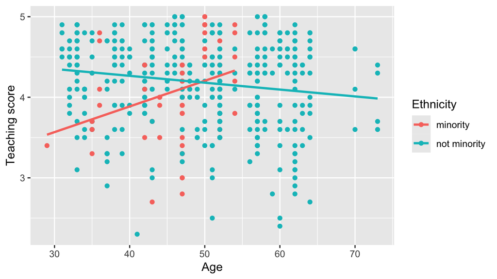

Visualization of interaction model.

```r
# Code to visualize interaction model:
ggplot(evals, aes(x = age, y = score, color = ethnicity)) +
  geom_point() +
  geom_smooth(method = "lm", se = FALSE) +
  labs(x = "Age", y = "Teaching score", color = "Ethnicity")
```

However, many introductory statistics courses start with the easier to teach “common slope, different intercepts” regression model, also known as the *parallel slopes* model. However, no argument to plot such models exists within `geom_smooth()`.

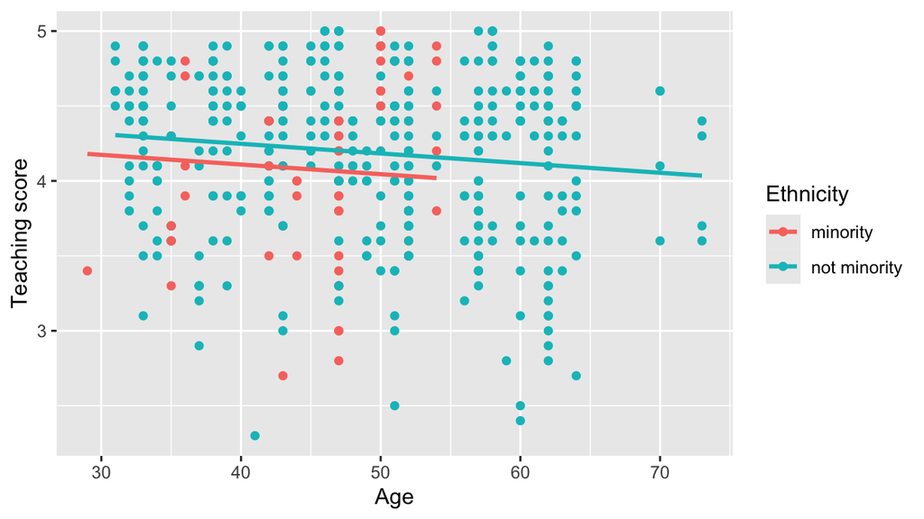

Visualization of parallel slopes model.

```r
# Code to visualize parallel slopes model:
ggplot(evals, aes(x = age, y = score, color = ethnicity)) +
  geom_point() +
  geom_parallel_slopes(se = FALSE) +
  labs(x = "Age", y = "Teaching score", color = "Ethnicity")
```

# Repository README

In the GitHub repository README, we present an in-depth discussion of six features of the `moderndive` package:

1. Focus less on p-value stars, more confidence intervals
2. Outputs as tibbles
3. Produce residual analysis plots from scratch using `ggplot2`
4. A quick-and-easy Kaggle predictive modeling competition submission!
5. Visual model selection: plot parallel slopes & interaction regression models
6. Produce metrics on the quality of regression model fits

Furthermore, we discuss the inner-workings of the `moderndive` package:

1. It leverages the `broom` package in its wrappers
2. It builds a custom `ggplot2` geometry for the `geom_parallel_slopes()` function that allows for quick visualization of parallel slopes models in regression.

# Author contributions

Albert Y. Kim and Chester Ismay contributed equally to the development of the `moderndive` package. Albert Y. Kim wrote a majority of the initial version of this manuscript with Chester Ismay writing the rest. Max Kuhn provided guidance and feedback at various stages of the package development and manuscript writing.

# Acknowledgments

Many thanks to Jenny Smetzer [@smetzer180](https://github.com/smetzer180), Luke W. Johnston [@lwjohnst86](https://github.com/lwjohnst86), and Lisa Rosenthal [@lisamr](https://github.com/lisamr) for their helpful feedback for this paper and to Evgeni Chasnovski [@echasnovski](https://github.com/echasnovski) for contributing the `geom_parallel_slopes()` function via GitHub [pull request](https://github.com/moderndive/moderndive/pull/55). The authors do not have any financial support to disclose.

# References

American Statistical Association Undergraduate Guidelines Workgroup. 2016. *“Guidelines for Assessment and Instruction in Statistics Education (GAISE) in Statistics Education (GAISE) College Report College Report 2016”*. American Statistical Association.

Diez, D. M., C. D. Barr, and M. Çetinkaya-Rundel. 2015. *OpenIntro Statistics*. OpenIntro, Incorporated. https://doi.org/10.5070/T573020084.

Ismay, Chester., and Albert Y. Kim. 2019. *Statistical Inference via Data Science: A ModernDive into r and the Tidyverse*. Chapman & Hall/CRC the r Series. CRC Press. https://doi.org/10.1080/00224065.2020.1848366.

Robinson, David, and Alex Hayes. 2019. *Broom: Convert Statistical Analysis Objects into Tidy Tibbles*. https://CRAN.R-project.org/package=broom.

Wickham, Hadley, Mara Averick, Jennifer Bryan, et al. 2019. “Welcome to the tidyverse.” *Journal of Open Source Software* 4 (43): 1686. https://doi.org/10.21105/joss.01686.

Wickham, Hadley, Winston Chang, Lionel Henry, et al. 2019. *ggplot2: Create Elegant Data Visualisations Using the Grammar of Graphics*. https://doi.org/10.1007/978-0-387-98141-3.

[^1]: For details on the remaining 5 variables, see the help file by running `?evals`.
[^2]: Note that `gender` was collected as a binary variable at the time of the study (2005).